# Data Analysis

Xiaoyang Li

2021/7/1

# Bar plot with proportion as well as odds ratio / univariate analysis

Plots below include information of

- Number of patients
- Proportion of Patients by success or not
- Odds ratio and its 95% confidence interval with the reference group (always the first subgroup)

by treatment and subgroup.

## age group

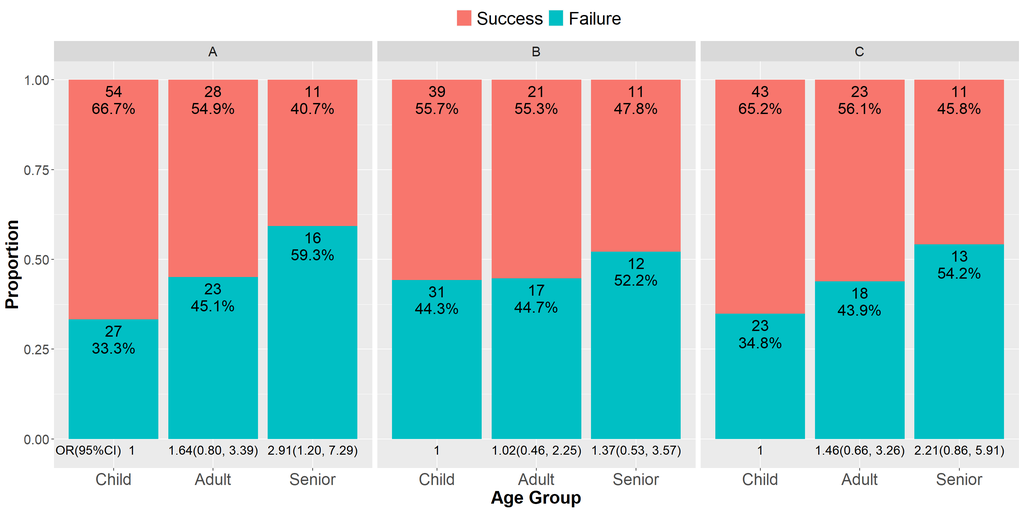

## gender

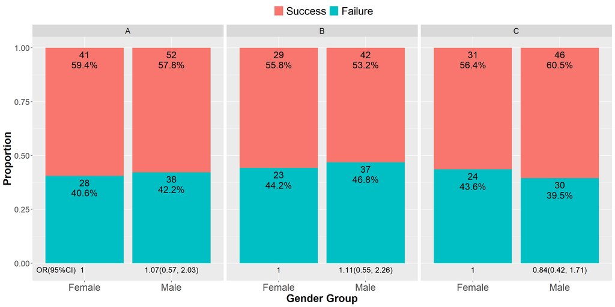

## Provoked or not

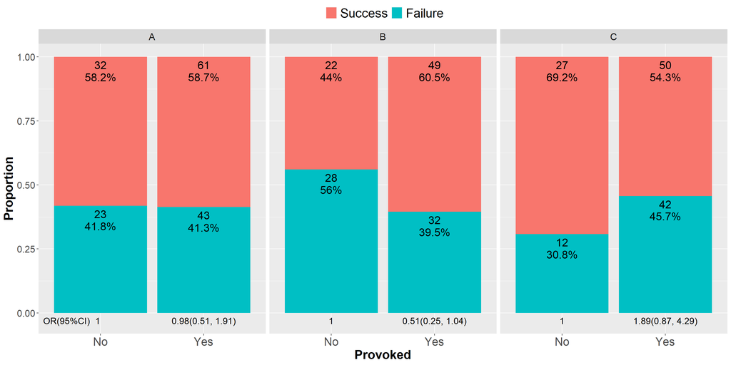

## Home antiepileptic medication

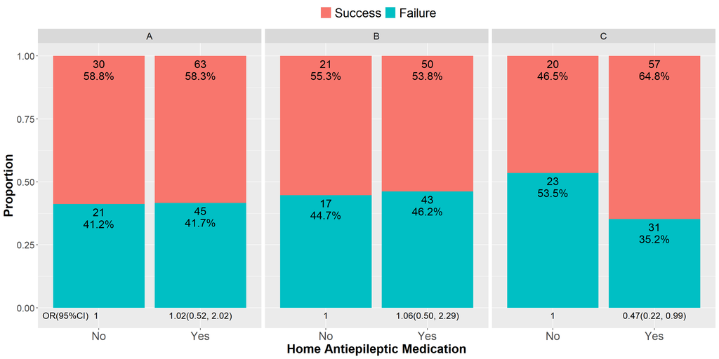

### Home use Drug A (Levetiracetam)

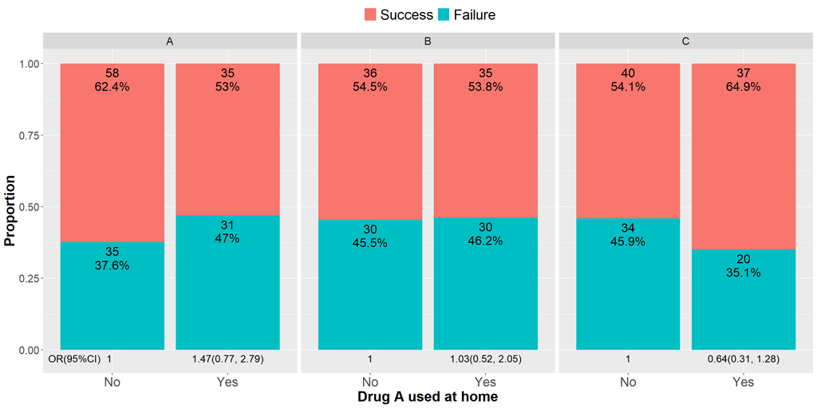

### No records show they have used Drug B before (Fosphenytoin)

### Home use Drug C (Valproate)

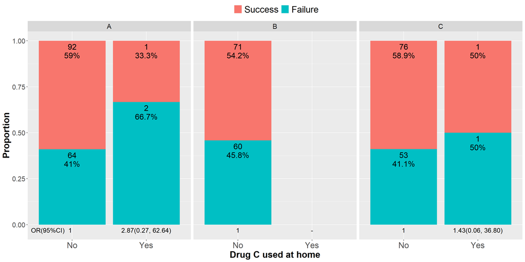

## Seizure duration 0/30/60/ (n = 392)

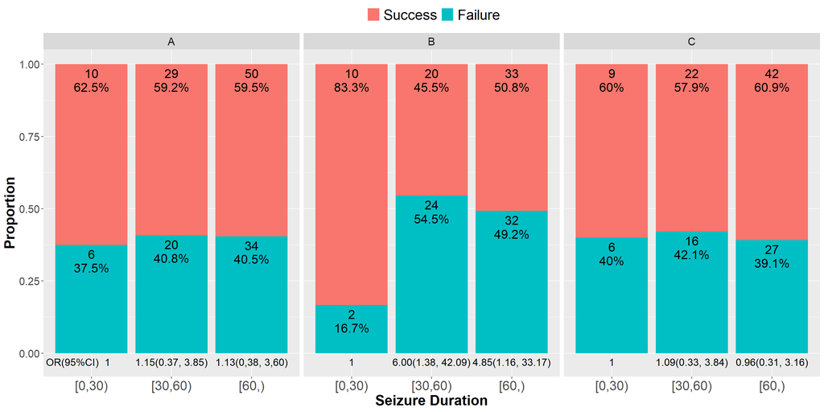

## Benzodiazepine prior to ED visit (n = 346)

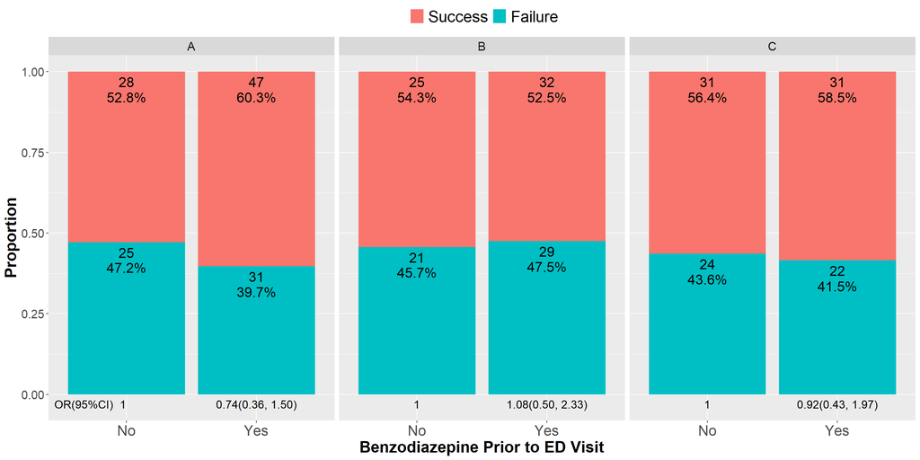

## Number of doses of benzodiazepine given prior to study drug

(3-7 doses vs 1-2 doses)

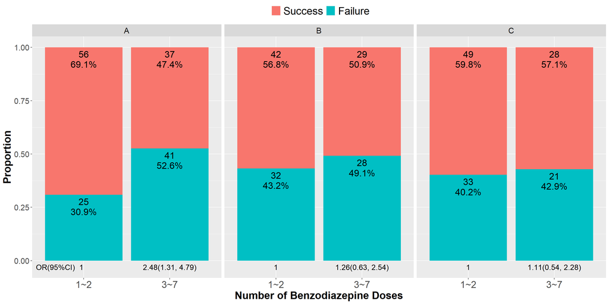

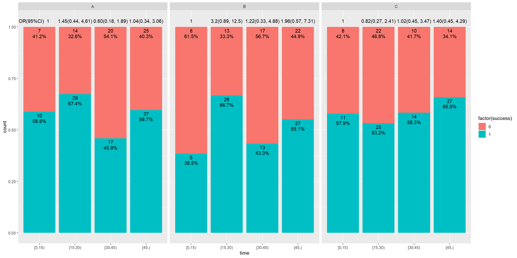

# Correaltion

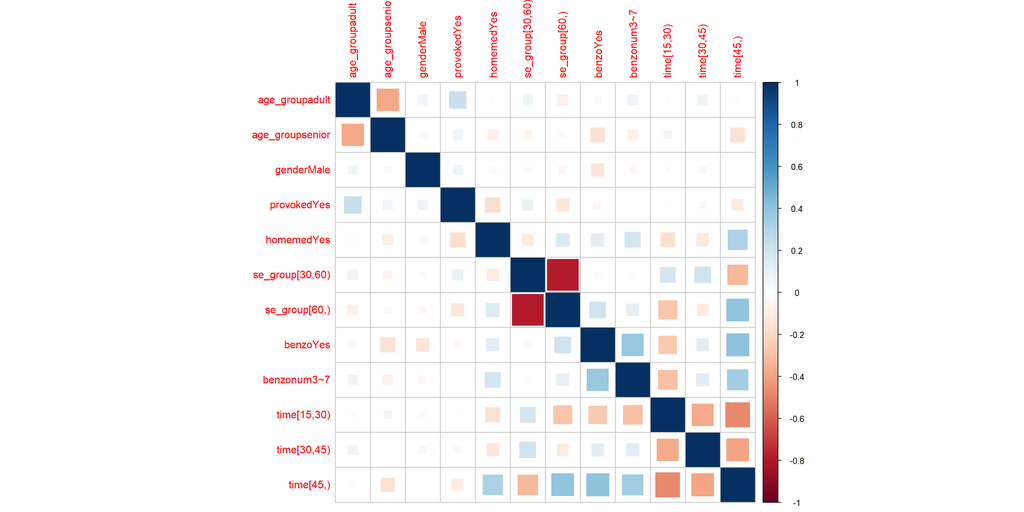

# Variable selection

## include 392 patients after remove NA in age_group, gender, provoked, homemed, se_group, benzonum

In this case, I exclude variables related to Benzodiazepine prior to ED visit and Time of 1st dose of benzodiazepine to time of study drug administration 0/15/30/45/. These 2 variable include large number of NAs. In addition, from the bar plot, univariate analysis, and above variable selection, they have none influence to Failure odds of drug B and drug C

After adjusting the forward selection threshold, all of three variable selection method generate the same results

For drug A, they generate formula as

$$Failure \sim age +benzonum$$

For drug B, they generate formula as

$$Failure \sim provoked + se\ group$$

For drug C, they generate formula as

$$Failure \sim homemed$$
*Provoked is the last removed variable*

## Interaction

$$Failure \sim (1 + drug)* (1 + age_group+gender+provoked+homemed+se_group+benzonum+ idmatchA)$$
Among all the variables listed above, only `age_groupsenior` and `benzonum3~7` show significant role.

When we include interaction between drug and other variables, none of them show significance in the prediction model, even if part of variables show drug difference in above univariate analysis.